# Praca domowa 2

Jakub Konieczny, nr indeksu: 320563

20.03.2023

# Wstęp

**Wykres, który będę poprawiał znalazłem na profilu poświęconym sportom motorowym na Twitterze - “Autosport”. Niestety moim zdaniem zawiera on kilka błędów, które mogły zostać celowo popełnione, aby nieco zmienić odbiór rzeczywistości. Ja jednak naprawię to i pokażę na moim wykresie prawdziwą sytuację.**  
**Źródło:** https://twitter.com/autosport/status/1634611535417933825

# Wykres znaleziony na Twitterze

[figure not shown]

# Wykres z grafiki powyżej, ale poprawiony

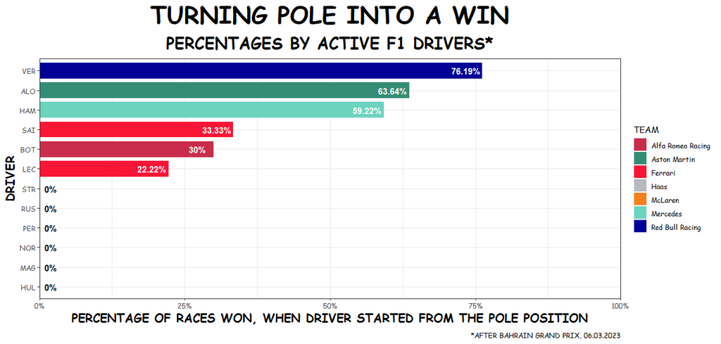

# Opis poprawek dokonanych na wykresie

**Stworzony przeze mnie wykres jest lepszy niż oryginalny, ponieważ:**

1. Oś X zaczyna się w 0, w przeciwieństwie do poprawianej wizualizacji. Tam nie ma skali i nie wiadomo, gdzie się co zaczyna. Słupki kierowców, których wynik to 0% mają tam pewną długość, co jest mylące i niepoprawne. U mnie słupki 0% nie figurują, co jest logiczne i ułatwia interpretację wyników.
2. Poprawiona została także długość poszczególnych słupków, które odpowiadają konkretnym kierowcom. Na moim wykresie proporcje zostały zachowane, dzięki czemu widzimy realne różnice między poszczególnymi wartościami. Łatwo zauważyć, że różnica między kierowcami VER (Max Verstappen), a ALO (Fernando Alonso) nie jest jednak aż taka duża, jak na poprawianym wykresie. Bardzo możliwe, że twórca tamtego wykresu jest fanem Maxa Verstappena i chciał podkoloryzować jego przewagę nad drugim w rankingu, niestety oszukując odbiorców. Widzimy też, że różnica między kierowcą HAM (Lewis Hamilton), a SAI (Carlos Sainz) jest znacznie większa niż zostało to przedstawione przez redakcję „Autosport” na Twitterze.
3. Poprawiłem także jeden aspekt czysto wizualny, dzięki czemu dla fanów Formuły 1 mój wykres będzie czytelniejszy. Słupek każdego z kierowców pokolorowałem kolorem, który odpowiada zespołowi, w którym występuje. Owe kolory są używane podczas transmisji wyścigów przy prezentacji wyników, czasów itp. Jest to bardzo naturalne dla osób, które są zainteresowane tematem. Dla osób niezorientowanych jest legenda: kolor – zespół. Na poprawianym wykresie wszystko było w jednym kolorze, co moim zdaniem było do poprawy.

# Kod, który napisałem, aby utworzyć poprawiony wykres

```r
#Biblioteki
library(ggplot2)
library(dplyr)
library(forcats)
library(scales)
library(shadowtext)
library(extrafont)
library(tidyverse)

#font_import()
loadfonts(device = "win", quiet = T)

#Kolumny potrzebne do utworzenia ramki danych
tag <- c("VER", "ALO", "HAM", "SAI", "BOT", "LEC", "HUL", "STR", "NOR", "PER", "RUS", "MAG")

"wins/poles" <- c("16/21", "14/22", "61/103", "1/3", "6/20", "4/18", "0/1", "0/1", "0/1", "0/1", "0/1", "0/1")

percentage <- c("76.19", "63.64", "59.22", "33.33", "30", "22.22", "0", "0", "0", "0", "0", "0")

team <- c("Red Bull Racing", "Aston Martin", "Mercedes", "Ferrari",
          "Alfa Romeo Racing","Ferrari","Haas", "Aston Martin",
          "McLaren","Red Bull Racing","Mercedes", "Haas")

#Tworze ramke danych
df <- data.frame(tag, `wins/poles`, percentage, team)

#Zmiana typu danych w kolumnie percentage z character na double
df$percentage <- as.double(df$percentage)

#Wykres
df %>%
  ggplot(aes(x = reorder(tag, percentage), y = percentage, fill = team)) +
  geom_col(width = 0.8, show.legend = T) +
  scale_y_continuous(labels = scales::number_format(suffix = "%"), expand = c(0,0)) +
  expand_limits(y = 100) +
  theme_bw() +
  labs(x = expression(paste(bold("DRIVER"))),
       y = expression(paste(bold("PERCENTAGE OF RACES WON, WHEN DRIVER STARTED FROM THE POLE POSITION"))),
       title = expression(paste(italic(bold("TURNING POLE INTO A WIN")))),
       subtitle = expression(paste(italic(bold("PERCENTAGES BY ACTIVE F1 DRIVERS*")))),
       caption = "*AFTER BAHRAIN GRAND PRIX, 06.03.2023") +
  coord_flip() +
  geom_text(data = subset(df, percentage >= 10),
            aes(label = paste(percentage, "%", sep = "")),
            nudge_y = -2.8,
            colour = "white",
            fontface='bold') +
  geom_text(data = subset(df, percentage < 10),
            aes(label = paste(0, "%", sep = "")),
            nudge_y = 2,
            colour = "black",
            fontface='bold') +
  scale_fill_manual(values=c("#C92D4B", "#358C75", "#F91536", "#B6BABD",
  "#F58020","#6CD3BF","#000097")) +
  theme(plot.title = element_text(hjust = 0.5, size = 30),
        plot.subtitle = element_text(hjust = 0.5, size = 20),
        axis.title = element_text(size = 15),
        text = element_text(family = "Comic Sans MS")) +
  guides(fill = guide_legend(title = "TEAM"))
```